# The Economic Problem

Economics

Paulo Fagandini

Universidade Europeia

# The Economic Problem

## The Economic Problem

The economic problem is the problem of how to make a choice in a world of scarcity.

## Choices and tradeoffs

Consider the following example:

> In general, the higher the degree, the higher the salaries.

Why then not everyone is pursuing higher degrees?

Choices and tradeoffs.

## How Individuals Make Choices Based on Their Budget Constraint

- **Budget constraint** - all possible consumption combinations of goods that someone can afford, given the prices of goods, when all income is spent; the boundary of the opportunity set.
- **Opportunity set** - all possible combinations of consumption that someone can afford given the prices of goods and the individual’s income (all income does not need to be spent).
- Given the price of the two goods and a budget amount, a budget constraint can be illustrated graphically.
- With a limited amount of income to spend on things, consumers must choose what they need and want.

## The Budget Constraint: Alphonso’s Consumption Choice

- Each point on the budget constraint represents a combination of burgers and bus tickets whose total cost adds up to Alphonso’s budget of $20.
- The slope of the budget constraint is determined by the relative price of burgers and bus tickets.
- Giving up one burger means gaining four bus tickets.
- **The opportunity set** - every point on (or inside) the constraint which shows a combination of burgers and bus tickets that Alphonso can afford.
- Any point outside the constraint is not affordable, because it would cost more money than Alphonso has in his budget.

## The Budget Constraint

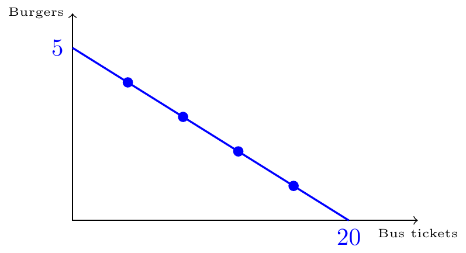

## The Concept of Opportunity Cost

- **Opportunity cost** indicates what people must give up to obtain what they desire.
  - The cost of one item is the lost opportunity to do or consume something else.
  - The opportunity cost is the value of the next best alternative.
  - A fundamental principle of economics is that every choice has an opportunity cost.
- For Alphonso, the opportunity cost of a burger is the four bus tickets he would have to give up.

## Identifying Opportunity Cost

- The price as measured in dollars may not accurately capture the true opportunity cost, such as when costs of time are involved.
  - Example: Attending college
    - The out-of-pocket costs of attending college include tuition, books, room and board, and other expenses.
    - Additionally, during the hours you are attending class and studying, it is impossible to work at a paying job.
    - So, college imposes both an out-of-pocket cost and an opportunity cost of lost earnings.

## Opportunity Cost Examples

- What are the opportunity costs of…
  - Buying vs. leasing a car
  - Investing in different ways (i.e., savings accounts, certificates of deposit, mutual funds, stocks, etc.)
  - Going out to eat vs. preparing food at home
  - Walking or taking public transportation

## Marginal Decision-Making and Diminishing Marginal Utility

- **Marginal analysis** - examining the benefits and costs of choosing a little more or a little less of a good.
- **Utility** - satisfaction, usefulness, or value one obtains from consuming goods and services.
- **Law of diminishing marginal utility** - as a person receives more of a good, the additional (or marginal) utility from each additional unit of the good declines.
  - *Example* - the first slice of pizza eaten brings more satisfaction than the sixth.

## Sunk Costs

- **Sunk costs** - costs that were incurred in the past and cannot be recovered.
- For people and firms alike, dealing with sunk costs can be frustrating.
  - *Example* - A firm finds it hard to give up on a new product that is doing poorly because much money was spent in creating and launching the product.
- The lesson of sunk costs is to ignore the past errors and make decisions based on what will happen in the future.

## Confronting Objections to the Economic Approach

Objections in understanding the economic approach to *decision-making*:

1. People, firms, and society do not act in a way that fits the economic way of thinking.
   - However, it is reasonable, as a first approximation, to analyze them with the tools of economic analysis.
   - Will be addressed in a later chapter on consumer choices.

## Confronting Objections to the Economic Approach

2. People, firms, and society should not act this way.
   - The economics approach:
     - Portrays people as self-interested, *but economics is not a form of moral instruction*.
     - Seeks to describe economic behavior as it actually exists.
     - Uses, **positive statements**, which describe the world as it is. These are factual.
     - Tries to avoid **normative statements**, which describe how the world should be. These statements are subjective questions of opinion.

## Confronting Objections to the Economic Approach

- **Invisible hand** - concept that individuals’ self-interested behavior can lead to positive social outcomes
  - Identified in Adam Smith’s The Wealth of Nations.
- Consumers will encourage businesses to offer goods and services that meet their needs.
- It is possible that broader social good can emerge from selfish individual actions.
- Self-interest in economics does not imply self-interest in all aspects of life.

## Reference

Shapiro, D.; MacDonald, D.; Greenlaw, S. A. (2022). Principles of Economics 3<sup>e</sup>. OpenStax.

Chapter 2